# Drought manipulation gas exchange

George Xenakis

2023-03-27

## Description

In the summer of 2022 the pilot study was concluded. For the experiment, European larch trees were used (available from a previous experiment). The drought experiment had two treatments, a control (C) and a “medium drought” (MD). The controlled treatment was watered at field capacity throughout the experiment. The drought treatment was watered for two weeks and then droughted for two weeks by stoping watering completely. Leaf level physiological measurements were conducted at the end of the watering and drought period respectively. There were 3-4 survey periods. During each measurement campaign I measured, cohort water potential (as a proxy for leaf water potential), soil water potential, soil water content, soil temperature, light curves, A/Ci curves, stomatal conductance and photosynthesis with a survey. In addition, sap flow and soil moisture content was measured continuously together with auxiliary variables, air temperature and relative humidity.

### Light curves

For each period for each tree light curves were conducted and models fitted to calculated the key physiological parameters.

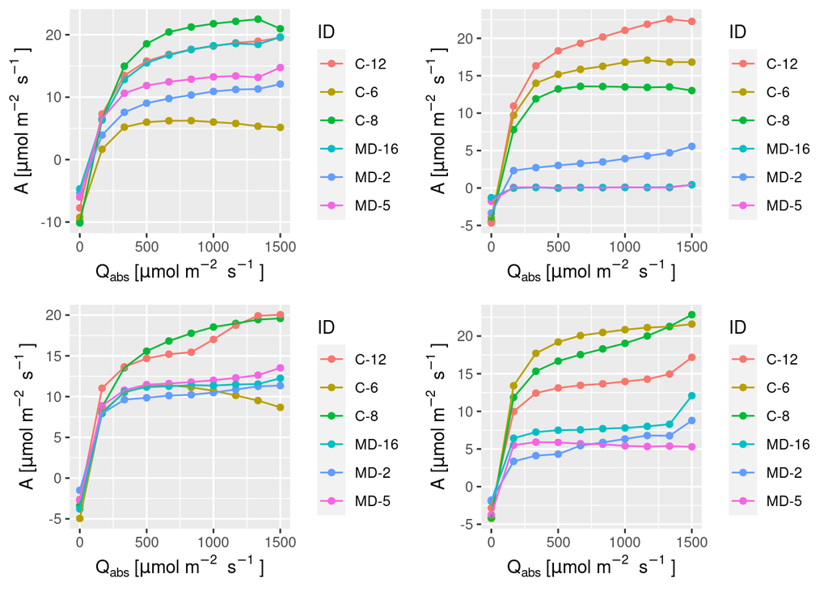

The parameters were then averaged for each survey date, for each treatment and compared to see the impact of wet-dry events.

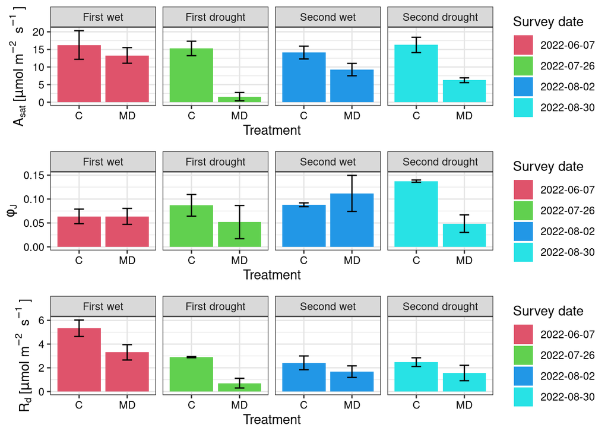

### A/Ci curves

The process was repeated for A/Ci curves. First, I plotted the curves.

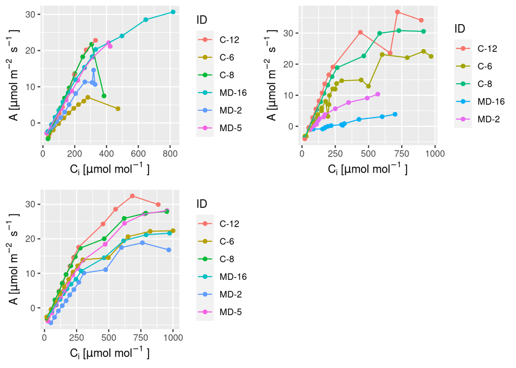

Then I fitted the parameters and average them across survey dates and treatments.

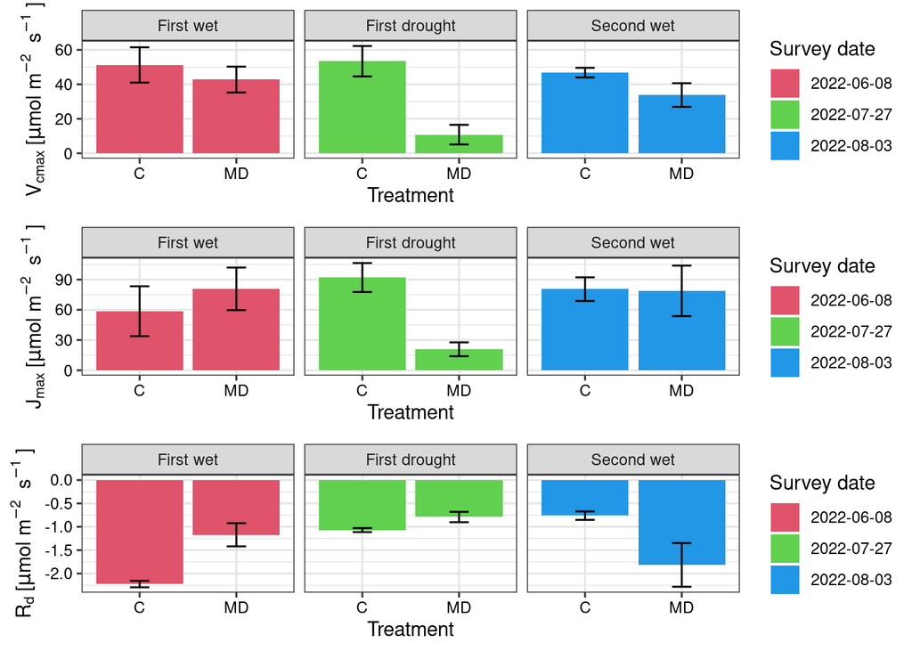

## Survey

Finally, along the light and A/Ci curves I conducted a survey of all the trees in each population measuring stomatal conductance and photosynthesis to get the mean for each treatment. Again, the mean was calculated per survey date per treatment.

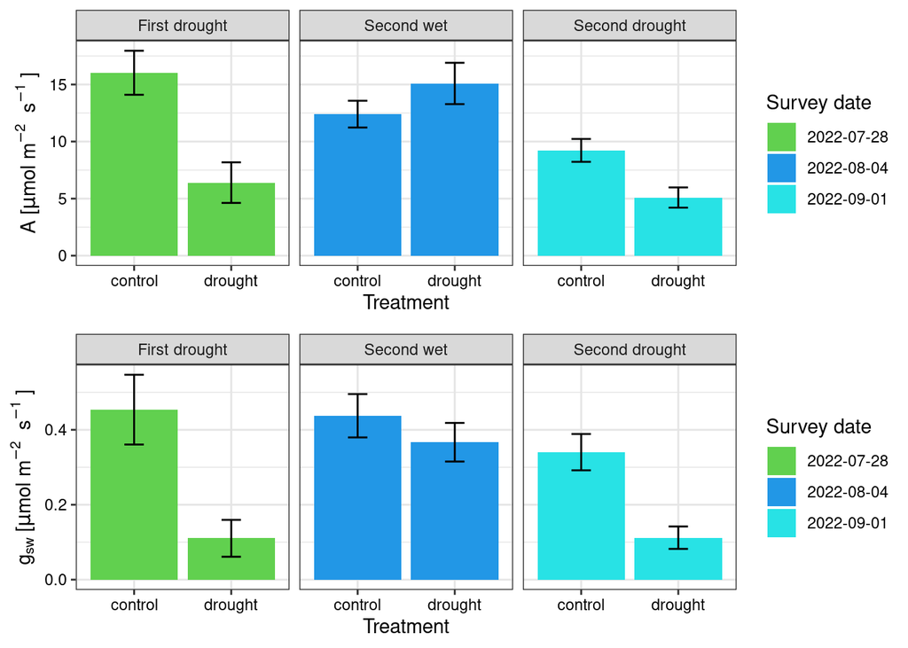